# 有哪些因素会让Titanic船上的人生还率更高？

## 数据导入和观察

### 导入需要的库

```python
import pandas as pd
import numpy as np
import seaborn as sns
sns.set()
import matplotlib.pyplot as plt
```

### 配置Jupyter Notebook

```python
%matplotlib inline
%config InlineBackend.figure_format = "retina"
```

### 导入数据

```python
titanic_data = pd.read_csv("titanic-data.csv")
titanic_data.head()
```

|  | PassengerId | Survived | Pclass | Name | Sex | Age | SibSp | Parch | Ticket | Fare | Cabin | Embarked |
| --- | --- | --- | --- | --- | --- | --- | --- | --- | --- | --- | --- | --- |
| 0 | 1 | 0 | 3 | Braund, Mr. Owen Harris | male | 22.0 | 1 | 0 | A/5 21171 | 7.2500 | NaN | S |
| 1 | 2 | 1 | 1 | Cumings, Mrs. John Bradley (Florence Briggs Th... | female | 38.0 | 1 | 0 | PC 17599 | 71.2833 | C85 | C |
| 2 | 3 | 1 | 3 | Heikkinen, Miss. Laina | female | 26.0 | 0 | 0 | STON/O2. 3101282 | 7.9250 | NaN | S |
| 3 | 4 | 1 | 1 | Futrelle, Mrs. Jacques Heath (Lily May Peel) | female | 35.0 | 1 | 0 | 113803 | 53.1000 | C123 | S |
| 4 | 5 | 0 | 3 | Allen, Mr. William Henry | male | 35.0 | 0 | 0 | 373450 | 8.0500 | NaN | S |

### 查看数据集概要信息

```python
titanic_data.info()
```

```
<class 'pandas.core.frame.DataFrame'>
RangeIndex: 891 entries, 0 to 890
Data columns (total 12 columns):
PassengerId    891 non-null int64
Survived       891 non-null int64
Pclass         891 non-null int64
Name           891 non-null object
Sex            891 non-null object
Age            714 non-null float64
SibSp          891 non-null int64
Parch          891 non-null int64
Ticket         891 non-null object
Fare           891 non-null float64
Cabin          204 non-null object
Embarked       889 non-null object
dtypes: float64(2), int64(5), object(5)
memory usage: 83.6+ KB
```

### 输出

### 默认显示数据集前5行数据

```python
titanic_data.head()
```

|  | PassengerId | Survived | Pclass | Name | Sex | Age | SibSp | Parch | Ticket | Fare | Cabin | Embarked |
| --- | --- | --- | --- | --- | --- | --- | --- | --- | --- | --- | --- | --- |
| 0 | 1 | 0 | 3 | Braund, Mr. Owen Harris | male | 22.0 | 1 | 0 | A/5 21171 | 7.2500 | NaN | S |
| 1 | 2 | 1 | 1 | Cumings, Mrs. John Bradley (Florence Briggs Th... | female | 38.0 | 1 | 0 | PC 17599 | 71.2833 | C85 | C |
| 2 | 3 | 1 | 3 | Heikkinen, Miss. Laina | female | 26.0 | 0 | 0 | STON/O2. 3101282 | 7.9250 | NaN | S |
| 3 | 4 | 1 | 1 | Futrelle, Mrs. Jacques Heath (Lily May Peel) | female | 35.0 | 1 | 0 | 113803 | 53.1000 | C123 | S |
| 4 | 5 | 0 | 3 | Allen, Mr. William Henry | male | 35.0 | 0 | 0 | 373450 | 8.0500 | NaN | S |

### 查寻整个数据集缺失值的个数

```python
titanic_data.isnull().sum()
```

```
PassengerId      0
Survived         0
Pclass           0
Name             0
Sex              0
Age            177
SibSp            0
Parch            0
Ticket           0
Fare             0
Cabin          687
Embarked         2
dtype: int64
```

### 可视化查询缺失值

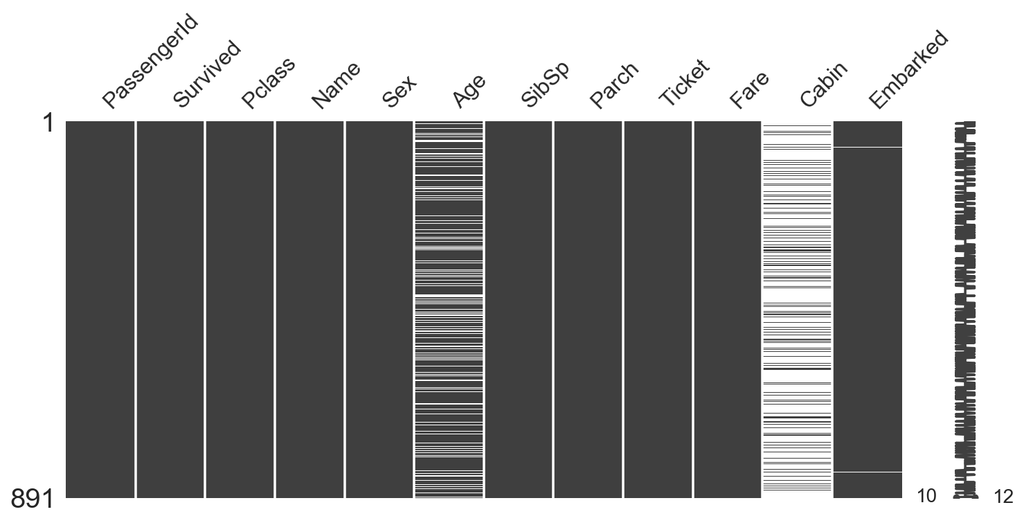

```python
import missingno as msno
msno.matrix(titanic_data,figsize=(12,5))
```

## 数据清洗

```python
### 求年龄的平均值，标准差以及丢失值的数量
```

```python
average_age_titanic   = titanic_data["Age"].mean()
std_age_titanic       = titanic_data["Age"].std()
count_nan_age_titanic = titanic_data["Age"].isnull().sum()
```

```python
### 求年龄随机数，范围在 (mean - std， mean + std)
```

```python
rand_1 = np.random.randint(average_age_titanic - std_age_titanic, average_age_titanic + std_age_titanic, size = count_nan_age_titanic)
```

```python
### 将随机数填充进 Age 的丢失值中
```

```python
titanic_data["Age"][np.isnan(titanic_data["Age"])]=rand_1
```

```python
## 年龄分布
```

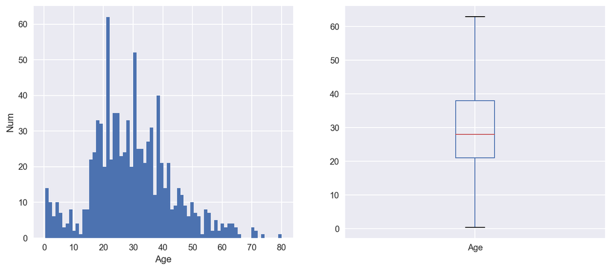

```python
plt.figure(figsize=(12,5))
plt.subplot(121)
titanic_data["Age"].hist(bins = 70)
plt.xlabel("Age")
plt.ylabel("Num")

plt.subplot(122)
titanic_data.boxplot(column="Age", showfliers=False)

plt.show()
```

### 查看Age列的描述统计值

```python
titanic_data.Age.describe()
```

```
count    891.000000
mean      29.639921
std       13.529566
min        0.420000
25%       21.000000
50%       28.000000
75%       38.000000
max       80.000000
Name: Age, dtype: float64
```

### 输出

## 数据可视化分析

### 891人当中，生还比率与未生还比率是多少？

```python
total_survived= titanic_data["Survived"].sum()
total = len(titanic_data)
total_no_survived = total - total_survived
```

### 创建画布

```python
plt.figure(figsize = (10,5))
```

### 添加第1个子图

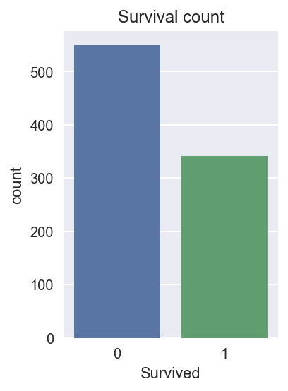

```python
plt.subplot(121)
sns.countplot(x="Survived", data=titanic_data)
plt.title("Survival count")
```

### 添加第2个子图

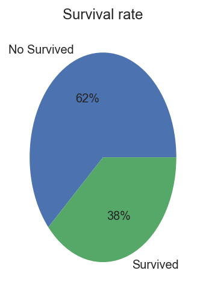

```python
total = len(titanic_data)
total_no_survived = total - total_survived
total_survived = titanic_data["Survived"].sum()
plt.subplot(122)
plt.pie([total_no_survived, total_survived],labels=["No Survived","Survived"],autopct="%1.0f%%")
plt.title("Survival rate")
```

```python
titanic_data["Survived_cat"] = titanic_data["Survived"].map({0:"no-survived",1:"survived"})
```

### 创建画布

### 添加第1个子图

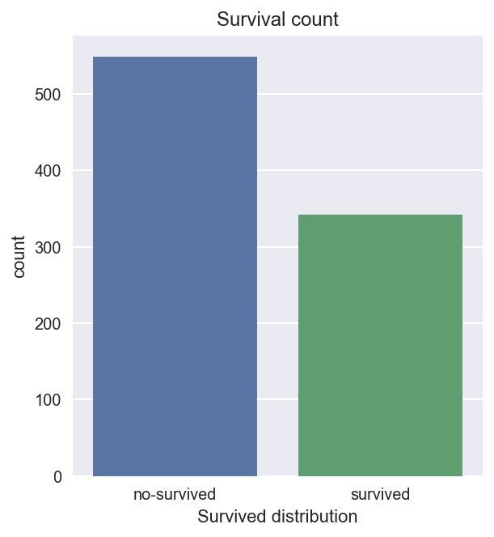

```python
plt.figure(figsize = (10,5))
plt.subplot(121)
sns.countplot(x="Survived_cat", data=titanic_data)
plt.xlabel("Survived distribution")
plt.title('Survival count')
```

### 添加第2个子图

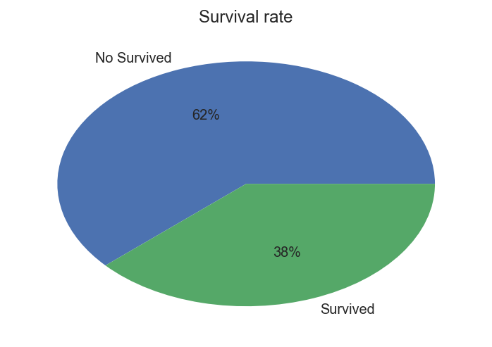

```python
total = len(titanic_data)
total_no_survived = total - total_survived
total_survived = titanic_data["Survived"].sum()
plt.pie([total_no_survived, total_survived],labels=["No Survived","Survived"],autopct="%1.0f%%")
plt.title("Survival rate")
```

### 数据中的这891名乘客，生还率与未生还率分别为38%和62%。

```python
titanic_data[["Pclass","Name"]].groupby(["Pclass"]).count()
```

| Pclass | Name |
| --- | --- |
| 1 | 216 |
| 2 | 184 |
| 3 | 491 |

### 创建画布

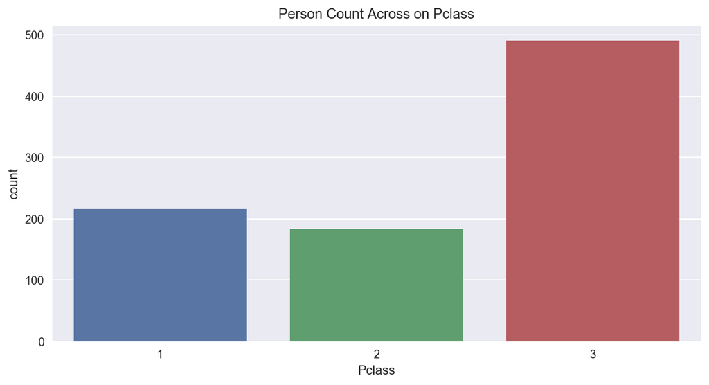

```python
plt.figure(figsize= (10 ,5))
sns.countplot(x="Pclass", data=titanic_data)
plt.title("Person Count Across on Pclass")
```

### 舱位与生还率的关系

```python
titanic_data.pivot_table(values="Survived",index="Pclass",aggfunc=np.mean)
```

| Pclass | Survived |
| --- | --- |
| 1 | 0.629630 |
| 2 | 0.472826 |
| 3 | 0.242363 |

```python
### ci表示置信区间
```

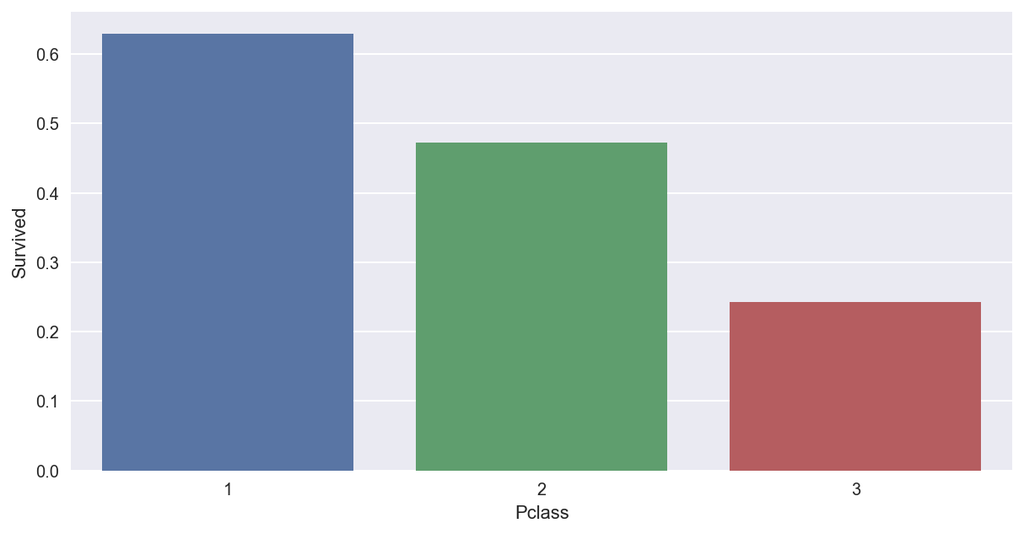

```python
plt.figure(figsize= (10 ,5))
sns.barplot(data=titanic_data,x="Pclass",y="Survived",ci=None)
```

### 三等舱的生还率最小，其次是二等舱，头等舱的生还率最大。

### 不同性别的生还率

```python
titanic_data.pivot_table(values="Survived",index="Sex",aggfunc=np.mean)
```

| Sex | Survived |
| --- | --- |
| female | 0.742038 |
| male | 0.188908 |

### 创建画布

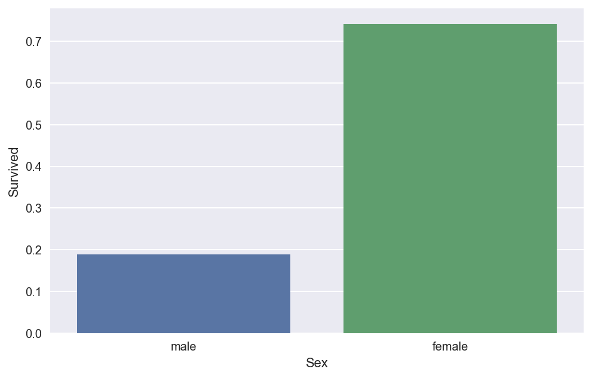

```python
plt.figure(figsize= (8 ,5))
sns.barplot(data=titanic_data,x="Sex",y="Survived",ci=None)
```

### 男性的幸存概远远小于女性。

### 年龄与生还率关系

### 将年龄列的数值划分为四等分

```python
bins=[0, 12, 18, 65, 100]
labels = ["Young","Juvenile", "Adult", "Old"]
titanic_data["AgeGroup"] = pd.cut(titanic_data["Age"], bins=bins, labels=labels)
```

### 查看每个分组有多少人数

```python
titanic_data.AgeGroup.value_counts(sort=False)
```

```
Young        69
Juvenile     95
Adult       719
Old           8
Name: AgeGroup, dtype: int64
```

### 输出

```python
titanic_data.pivot_table(values="Survived",index="AgeGroup",aggfunc=np.mean)
```

| AgeGroup | Survived |
| --- | --- |
| Young | 0.579710 |
| Juvenile | 0.400000 |
| Adult | 0.365786 |
| Old | 0.125000 |

### 设置刻度标签角度

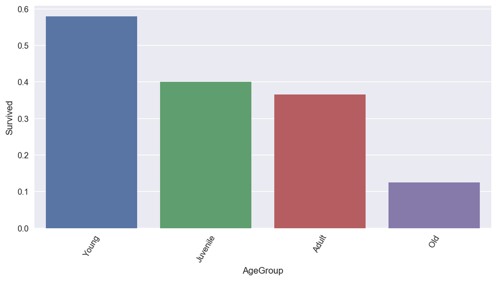

```python
plt.figure(figsize= (10 ,5))
sns.barplot(data=titanic_data,x="AgeGroup",y="Survived",ci=None)
plt.xticks(rotation=60)
```

```python
### 登船码头与生还率的关系
```

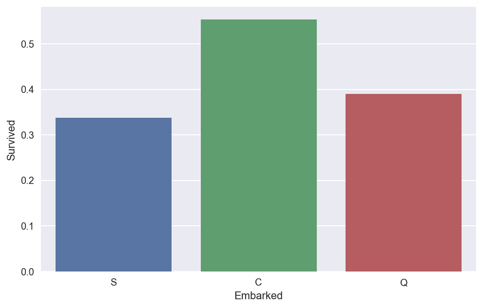

```python
plt.figure(figsize= (8 ,5))
sns.barplot(data=titanic_data,x="Embarked",y="Survived",ci=None)
```

### 从S处上船的生还率最低，Q处次之，C处最低高。

### 综合多个因素看生还率

### 年龄、性别、舱位、登船码头与生还率的关系

```python
titanic_data.pivot_table(values="Survived",index="AgeGroup",columns=["Sex","Pclass","Embarked"],aggfunc=np.mean)
```

| Sex Pclass Embarked AgeGroup | female 1 C | female 1 Q | female 1 S | female 2 C | female 2 Q | female 2 S | female 3 C | female 3 Q | female 3 S | male 1 C | male 1 Q | male 1 S | male 2 C | male 2 Q | male 2 S | male 3 C | male 3 Q | male 3 S |
| --- | --- | --- | --- | --- | --- | --- | --- | --- | --- | --- | --- | --- | --- | --- | --- | --- | --- | --- |
| Young | NaN | NaN | 0.00000 | 1.0 | NaN | 1.000000 | 0.833333 | NaN | 0.352941 | NaN | NaN | 1.000000 | 1.000000 | NaN | 1.00000 | 0.666667 | 0.000000 | 0.388889 |
| Juvenile | 1.000000 | NaN | 1.00000 | 1.0 | NaN | 1.000000 | 0.625000 | 0.875 | 0.333333 | 0.500000 | NaN | NaN | NaN | NaN | 0.00000 | 0.000000 | 0.000000 | 0.090909 |
| Adult | 0.973684 | 1.0 | 0.97561 | 1.0 | 1.0 | 0.892857 | 0.555556 | 0.680 | 0.389831 | 0.416667 | 0.0 | 0.324324 | 0.111111 | 0.0 | 0.08642 | 0.222222 | 0.096774 | 0.112676 |
| Old | NaN | NaN | NaN | NaN | NaN | NaN | NaN | NaN | NaN | 0.000000 | NaN | 0.500000 | NaN | NaN | 0.00000 | NaN | 0.000000 | 0.000000 |

### 可视化分析操作

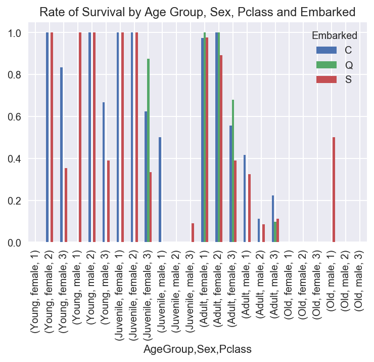

```python
survived_rate = (titanic_data.groupby(["AgeGroup", "Sex", "Pclass", "Embarked"]).mean())["Survived"].unstack()
survived_rate.plot(kind="bar", stacked=False)
plt.title("Rate of Survival by Age Group, Sex, Pclass and Embarked")
```

# 结论

### 891人中，从S处上船的生还率最低，Q处次之，C处最低高。

### 报告中仅使用了Exploratory Data Analysis，所以至多只能得出相关关系，而不能得出因果关系。